# Prova de R in Rio

Pedro Pablo Skorin

September 24, 2020

## Introdução

Obrigado pela oportunidade em participar da prova. Para a realização dos exercícios, utilizei o pacote *tidyverse* nas questões 2 e 3.

## Questão 1

### Objetivo

Escrever uma função que recebe um vetor numérico e devolve os seus *k* maiores valores. Se o vetor de entrada não for numérico, fazer com que a função devolva um erro informativo. Além disso, fazer com que o usuário possa escolher entre os maiores ou os menores valores do vetor.

### Resolução

A resolução se encontra no cógido abaixo. O usuário pode escolher se quer os maiores ou menores valores do vetor pelo argumento *min*. O padrão da função é responder com os maiores valores do vetor, entretanto ao selecionar *min = T* os menores valores serão devolvidos.

```r
extremos = function(X, k, min = F) {
  # Primeiro fazemos a verificacao da classe do vetor. Se quisermos incluir vetores do formato 'integer', basta substituir a condicao de erro para '!(class(X) %in% c("numeric", "integer"))'
  if(class(X) != "numeric") {
    stop("O vetor precisa ser da classe 'numeric'")
  }
  # Ordenamos o vetor X (de forma crescente ou decrescente) e escolhemos os primeiros k elementos
  Y = X[order(X, decreasing = !min)][1:k]
  return(Y)
}
```

### Exemplos

```r
# Exemplo de 3 maiores elementos
extremos(c(1,2,3,pi,4,5), 3, min = F)
```

```
## [1] 5.000000 4.000000 3.141593
```

```r
# Exemplo de 3 menores elementos
extremos(c(1,2,2,pi,5,5), 3, min = T)
```

```
## [1] 1 2 2
```

```r
# Exemplo de vetor classe 'character'
extremos(c(1,2,3,"pi",4,5), 4, min = F)
```

```
## Error in extremos(c(1, 2, 3, "pi", 4, 5), 4, min = F): O vetor precisa ser da classe 'numeric'
```

## Questão 2

### Objetivo

Gerar um dataframe contendo um vetor contendo os 100 primeiros números inteiros. Para cada número *n* simular 100 números tirados de uma normal com média *n*.

### Resolução

A resolução se encontra no cógido abaixo.

```r
library(tidyverse)

# Criacao da funcao que sera realizada em todos esses inteiros. Pode-se alterar os valores de n e sd se necessario
NormFunc <- function(x) {rnorm(n = 100, mean = x, sd = 1)}

# Aplicacao da funcao via purrr
Y = seq(1,100) %>%
  map(NormFunc) %>%
  map_dfr(~as.data.frame(t(.x))) %>%
  mutate(seq(1,100))
```

*Y* representa uma *dataframe* de 100 linhas e 101 colunas. As primeiras 100 colunas representam as simulacoes dos números tiradas de normal com media *n*, onde *n* representa a linha da *dataframe*. A última coluna representa a sequência geradora das médias. Note que temos as dimensões desejadas.

```r
dim(Y)
```

```
## [1] 100 101
```

Para verificar o resultado, fazemos a seleção de 5 linhas e 5 colunas aleatórias da *dataframe*.

```r
print(Y[sample(1:100,5),c(sample(1:100,5))])
```

```
##         V11      V27      V13      V90      V51
## 97 96.23140 96.67628 97.77675 97.64435 96.60421
## 50 51.32821 50.44575 49.69006 48.98023 50.26546
## 72 72.44406 72.01931 72.31480 71.80552 73.48460
## 21 20.82632 21.37657 20.45554 22.51677 20.61743
## 66 67.11248 66.84868 66.53469 65.98333 67.07538
```

## Questão 3

### Objetivo

Transformar os dados recebidos em formato *tidy*.

### Resolução

Primeiro carregamos os dados do site.

```r
library(rio)
(data <- import("https://www.rug.nl/ggdc/docs/10sd_jan15_2014.xlsx",
                sheet = 2, setclass = "tibble") %>%
    filter(Variable == "VA_Q05" | Variable == "EMP") %>%
    select(-'Region code', -'Summation of sector GDP'))
```

```
## # A tibble: 4,980 x 14
##    Country Region Variable  Year Agriculture Mining Manufacturing Utilities
##    <chr>   <chr>  <chr>    <dbl>       <dbl>  <dbl>         <dbl>     <dbl>
##  1 BWA     Sub-s~ VA_Q05    1960         NA    NA           NA        NA
##  2 BWA     Sub-s~ VA_Q05    1961         NA    NA           NA        NA
##  3 BWA     Sub-s~ VA_Q05    1962         NA    NA           NA        NA
##  4 BWA     Sub-s~ VA_Q05    1963         NA    NA           NA        NA
##  5 BWA     Sub-s~ VA_Q05    1964        345.  200.           8.69      3.67
##  6 BWA     Sub-s~ VA_Q05    1965        333.  143.          12.0       4.75
##  7 BWA     Sub-s~ VA_Q05    1966        375.  113.           9.48      7.12
##  8 BWA     Sub-s~ VA_Q05    1967        406.  132.          11.1       7.12
##  9 BWA     Sub-s~ VA_Q05    1968        462.   96.6         16.3       7.12
## 10 BWA     Sub-s~ VA_Q05    1969        463.  261.          46.5      13.1
## # ... with 4,970 more rows, and 6 more variables: Construction <dbl>,
## #   `Trade, restaurants and hotels` <dbl>, `Transport, storage and
## #   communication` <dbl>, `Finance, insurance, real estate and business
## #   services` <dbl>, `Government services` <dbl>, `Community, social and
## #   personal services` <dbl>
```

Utilizamos as funções *pivot* para transformação dos dados em *tidy*.

Primeiro utilizaremos a função *pivot_longer* para transformar as últimas 10 colunas em um novo formato distribuido em linhas. O resultado da operação está exemplificado na imagem abaixo:

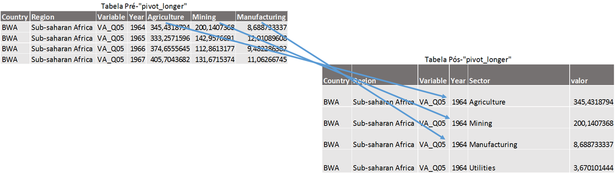

Depois disso, utilizaremos a função *pivot_wider* para levar as opções *VA_Q05* e *EMP* da coluna *Variable* para duas novas colunas. O resultado da operação está exemplificado na imagem abaixo:

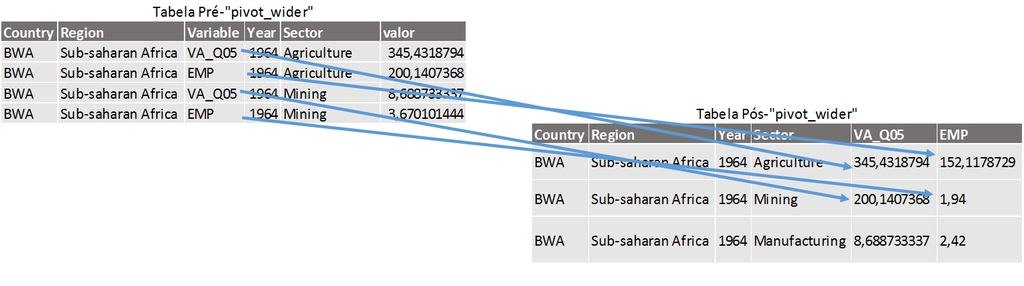

```r
data_tidy = data %>%
  # Primeiro aplicamos o pivot_longer
  pivot_longer(colnames(data)[5:14], names_to = "Sector", values_to = "valor") %>%
  # Então aplicamos o pivot_wider
  pivot_wider(names_from = Variable, values_from = valor)

# Agora apagam-se as linhas que contenham NA
data_tidy = na.omit(data_tidy)

data_tidy
```

```
## # A tibble: 20,954 x 6
##    Country Region         Year Sector                         VA_Q05    EMP
##    <chr>   <chr>         <dbl> <chr>                           <dbl>  <dbl>
##  1 BWA     Sub-saharan ~  1964 Agriculture                    345.   152.
##  2 BWA     Sub-saharan ~  1964 Mining                         200.     1.94
##  3 BWA     Sub-saharan ~  1964 Manufacturing                    8.69   2.42
##  4 BWA     Sub-saharan ~  1964 Utilities                        3.67   0.12
##  5 BWA     Sub-saharan ~  1964 Construction                   142.     2.70
##  6 BWA     Sub-saharan ~  1964 Trade, restaurants and hotels  328.     2.47
##  7 BWA     Sub-saharan ~  1964 Transport, storage and commun~  23.3    2.32
##  8 BWA     Sub-saharan ~  1964 Finance, insurance, real esta~  24.2    1.21
##  9 BWA     Sub-saharan ~  1964 Government services            173.     4.51
## 10 BWA     Sub-saharan ~  1964 Community, social and persona~  30.2    4.07
## # ... with 20,944 more rows
```

## Questão 4

### Objetivo

Fazer uma função que recebe um vetor e testa seu tipo. Se for numérico, devolve a média, se for textual, tem dois retornos possíveis:

• Se mais de um terço das entradas for única, devolver o número médio de caracteres por entrada.

• Se menos de um terço das entradas for única, devolver a entrada mais comum.

### Resolução

A resolução se encontra no cógido abaixo. A função *q_4* recebe um vetor *X* e devolve um elemento a depender dos critérios estabelecidos no objetivo da questão.

```r
q_4 = function(X) {
  # Teste de classe numerica. Como no exercicio 1, se quisermos incluir a classe 'integer', basta alterar a condicao abaixo para 'class(X) %in% c("numeric","integer")'
  if (class(X) == "numeric") {
    return(mean(X))
  }
  # Teste de classe texto
  if (class(X) == "character") {
    # Construcao da proporcao de unicos com total no vetor para verificacao
    unica = length(unique(X))/length(X)
    if (unica <= 1/3) {
      # No caso de menos de um terco unico, retorno da entrada mais comum. Para isso, constroe-se uma tabela das aparicoes de ux (vetor com unicos de X) em X. O objetivo eh garantir a mensuracao de quantes vezes aparecem ux em X. Disso se seleciona o valor com mais aparicoes na tabela
      ux <- unique(X)
      return(ux[which.max(tabulate(match(X, ux)))])
    } else {
      # No caso de mais de um terco unico, retorno do numero medio de caracteres. Isso eh feito via aplicacao da media no mapeamente de nchar sobre X
      return(mean(mapply(nchar, X)))
    }
  }
}
```

### Exemplos

```r
# Exemplo de vetor numerico
q_4(c(-4,-3,-2,-1,0,1,2,3,4))
```

```
## [1] 0
```

```r
# Exemplo de vetor texto com menos de um terco de elementos unicos
X = c(rep("Brasil", 10), rep("Argentina", 5), rep("Uruguai", 2), rep("Chile", 1))
list("razao" = length(unique(X))/length(X),
     "q_4" = q_4(X))
```

```
## $razao
## [1] 0.2222222
##
## $q_4
## [1] "Brasil"
```

```r
# Exemplo de vetor texto com mais de um terco de elementos unicos
X = c(rep("Brasil", 2), rep("Argentina", 2), rep("Uruguai", 2), rep("Chile", 2))
list("razao" = length(unique(X))/length(X),
     "q_4" = q_4(X))
```

```
## $razao
## [1] 0.5
##
## $q_4
## [1] 6.75
```

## Questão 5

### Objetivo

Escrever uma função que recebe um parâmetro *n* e devolve a sequência de Fibonacci até o *n*-ésimo elemento. Além disso, fazer com que o usuário possa dar como argumento algum valor *TRUE/FALSE* para um parâmetro e isso alternar o retorno da função entre a sequência completa até *n* ou apenas o *n*-ésimo elemento.

### Resolução

Para realizar o exercício, eu me baseei na explicação encontrada em https://stackoverflow.com/questions/18172257/efficient-calculation-of-fibonacci-series. Primeiramente, perceba como é dada a sequência de Fibonacci:

O código consistirá na construção “de baixo para cima” dessa sequência. A função *fib* recebe o argumento *n* que significa até que elemento será devolvida a sequência de Fibonacci. Se a usuária quiser exatamante o elemento *n*, ela pode modificar o argumento *exato* para opção *TRUE*.

```r
fib = function(n, exato = F) {
  # Como o objetivo nao eh possivel para inteiros menores que 1, precisamos verificar a entrada de n
  if (n < 1 | n != round(n)) {
    stop("n deve ser um número inteiro maior que 0")
  }
  # Inclusao dos dois primeiros valores da sequencia
  fibs = c(0,1)
  # Para os restantes utilizaremos a formulacao de Fibonacci com n > 1
  if (n > 1) {
    for (i in 1:(n-1)) {
      fibs = append(fibs, tail(fibs,1) + tail(fibs,2)[1])
    }
  }
    # Se quisermos o valor exato, basta solicitar pelo ultimo elemento da sequencia  criada
  if (exato) {
    return(tail(fibs,1))
  } else {
      # Se quisermos a sequencia inteira, basta solicitar diretamente a sequencia criada
  return(fibs)
  }
}
```

### Exemplos

```r
# Exemplo dos primeiros 15 termos
fib(15)
```

```
##  [1]   0   1   1   2   3   5   8  13  21  34  55  89 144 233 377 610
```

```r
# Exemplo do termo numero 10
fib(10, exato = T)
```

```
## [1] 55
```

```r
# Exemplo de solicitacao de numero negativo
fib(-4)
```

```
## Error in fib(-4): n deve ser um número inteiro maior que 0
```

```r
# Exemplo de solicitacao de numero nao inteiro
fib(pi)
```

```
## Error in fib(pi): n deve ser um número inteiro maior que 0
```